# Dalton_WSU_RData

Rebecca M. Dalton

7/20/2020

## Before we start, we will install the neccessary packages:

```r
# To install the collection of tidyverse packages:

  #install.packages("devtools")
  #devtools::install_github("tidyverse/tidyverse")
  #library(tidyverse)

# For this presentation, we will only use dplyr and ggplot2

# install.packages("dplyr", "ggplot2", "tidyr", lubridate", "ggpubr")
  library(dplyr)
  library(tidyr)
  library(ggplot2)
  library(lubridate)
  library(ggpubr)
```

## RMBL data collected by billy barr

long-term snow data accessed on July 10, 2020: http://www.gothicwx.org/long-term-snow.html

# Goal 1: Plot monthly snowfall data

1.1: Load data and remove excess headers from the data frame

```r
s <- read.csv("barr_snowdata_gothic_2020.csv", header= T, sep=",") # read in data

head(s) # look at the top six rows of data
```

```
##   Winter.of Sept. Oct. Nov. Dec. Jan Feb Mar Apr May June July Total X1.Apr
## 1   1974-75     2   66   66   97 202 158 218 120 112   32    0  1073    213
## 2   1975-76     1   43  157   93 139 300 132  81  14    6    0   966    137
## 3   1976-77     6   18   57   18  89  67 104  78  37    0    0   474     74
## 4   1977-78     0   18  122  269 231 234 289 131  91    2    0  1387    179
## 5   1978-79     1   23  112  306 340 141 172  63 151   37    0  1346    216
## 6   1979-80     0   20  213   57 441 363 259  90  99    0    0  1542    235
##   X1.May on.grnd.
## 1    152    6-Jun
## 2     76   15-May
## 3      0   26-Apr
## 4    137    4-Jun
## 5    130    1-Jun
## 6    165    7-Jun
```

```r
tail(s) # look at the bottom six rows of data
```

```
##    Winter.of Sept. Oct. Nov. Dec. Jan Feb Mar Apr May June July Total X1.Apr
## 44   2015-16     0   24   98  217 119  71 104 123  80    1    0   837    110
## 45   2016-17    16    9   94  171 375 166  37  80  30    0    0   978    148
## 46   2017-18     2   43   56   55  76 113  56  76  13    0    0   490     89
## 47   2018-19     0   62  105   91 147 117 242  87 108    8    0   967    180
## 48   2019-20     0   50   46  115  76  82 146  63  10   14        602    114
## 49           Sept. Oct. Nov. Dec. Jan Feb Mar Apr May June July Total  1-Apr
##    X1.May   on.grnd.
## 44     65     18-May
## 45     96     24-May
## 46      6      5-May
## 47    149      6-Jun
## 48     43      8-May
## 49  1-May 0 on grnd.
```

```r
dim(s) # this command tells you the number of rows and columns
```

```
## [1] 49 16
```

```r
lev <- lapply(s, levels)

# Use base R to remove the rows with a blank cell in the "Winter.of" column
s1 <-  s[!(s$Winter.of == ""), ]
  dim(s1)
```

```
## [1] 46 16
```

```r
# Alteratively, we could use dplyr
s2 <- s %>% filter(Winter.of != "")
  # filter() allows you to subset rows of a data frame based on column values
    # keep the rows that are not blank in the “Winter.of” column
  dim(s2)
```

```
## [1] 46 16
```

```r
  tail(s2)
```

```
##    Winter.of Sept. Oct. Nov. Dec. Jan Feb Mar Apr May June July Total X1.Apr
## 41   2014-15    11   37  159  128  68  92 103  92 162    0    0   852     71
## 42   2015-16     0   24   98  217 119  71 104 123  80    1    0   837    110
## 43   2016-17    16    9   94  171 375 166  37  80  30    0    0   978    148
## 44   2017-18     2   43   56   55  76 113  56  76  13    0    0   490     89
## 45   2018-19     0   62  105   91 147 117 242  87 108    8    0   967    180
## 46   2019-20     0   50   46  115  76  82 146  63  10   14        602    114
##    X1.May on.grnd.
## 41     14    7-Apr
## 42     65   18-May
## 43     96   24-May
## 44      6    5-May
## 45    149    6-Jun
## 46     43    8-May
```

1.2: Convert snow columns to "numeric" values instead of "factors"

```r
head(s2)
```

```
##   Winter.of Sept. Oct. Nov. Dec. Jan Feb Mar Apr May June July Total X1.Apr
## 1   1974-75     2   66   66   97 202 158 218 120 112   32    0  1073    213
## 2   1975-76     1   43  157   93 139 300 132  81  14    6    0   966    137
## 3   1976-77     6   18   57   18  89  67 104  78  37    0    0   474     74
## 4   1977-78     0   18  122  269 231 234 289 131  91    2    0  1387    179
## 5   1978-79     1   23  112  306 340 141 172  63 151   37    0  1346    216
## 6   1979-80     0   20  213   57 441 363 259  90  99    0    0  1542    235
##   X1.May on.grnd.
## 1    152    6-Jun
## 2     76   15-May
## 3      0   26-Apr
## 4    137    4-Jun
## 5    130    1-Jun
## 6    165    7-Jun
```

```r
s3 <-  s2 %>% mutate_at(vars(-Winter.of, -on.grnd.), as.character) %>%
              mutate_at(vars(-Winter.of, -on.grnd.), as.numeric)
head(s3)
```

```
##   Winter.of Sept. Oct. Nov. Dec. Jan Feb Mar Apr May June July Total X1.Apr
## 1   1974-75     2   66   66   97 202 158 218 120 112   32    0  1073    213
## 2   1975-76     1   43  157   93 139 300 132  81  14    6    0   966    137
## 3   1976-77     6   18   57   18  89  67 104  78  37    0    0   474     74
## 4   1977-78     0   18  122  269 231 234 289 131  91    2    0  1387    179
## 5   1978-79     1   23  112  306 340 141 172  63 151   37    0  1346    216
## 6   1979-80     0   20  213   57 441 363 259  90  99    0    0  1542    235
##   X1.May on.grnd.
## 1    152    6-Jun
## 2     76   15-May
## 3      0   26-Apr
## 4    137    4-Jun
## 5    130    1-Jun
## 6    165    7-Jun
```

1.3: Subset the data frame to only include monlthy snowfall totals

```r
# base R
s.month <- s3[c(1:12)]

# dplyr:
s.month <- s3 %>% select(Winter.of:July)
  # use select() to keep or exclude columns of a data frame
    # keep all of the columns from Winter.of -> July
```

1.4: Reshape (or rearrange) the monthly data from wide to long format

```r
s.month.gathered <- s.month %>%
                    gather(key = "month.name",
                           value = "snow.cm", "Sept.":"July",
                           na.rm = F) %>%
                     arrange(Winter.of)
head(s.month.gathered)
```

```
##   Winter.of month.name snow.cm
## 1   1974-75      Sept.       2
## 2   1974-75       Oct.      66
## 3   1974-75       Nov.      66
## 4   1974-75       Dec.      97
## 5   1974-75        Jan     202
## 6   1974-75        Feb     158
```

```r
s.month$Winter.of <- as.character(s.month$Winter.of)
```

1.5: Separate the "Winter.of" column into two year columns: year.1 and year.2

```r
s.month.sep <- s.month.gathered %>%
                separate(Winter.of, c("year.1", "year.2"),
                          sep ="-", remove = F)  %>%
                mutate(year.1 = as.numeric(year.1))
head(s.month.sep)
```

```
##   Winter.of year.1 year.2 month.name snow.cm
## 1   1974-75   1974     75      Sept.       2
## 2   1974-75   1974     75       Oct.      66
## 3   1974-75   1974     75       Nov.      66
## 4   1974-75   1974     75       Dec.      97
## 5   1974-75   1974     75        Jan     202
## 6   1974-75   1974     75        Feb     158
```

1.6: Convert the monthly column name from characters into numbers. It will be easier to work with for summaries or combining with other data sets.

```r
s.month.num <- s.month.sep %>%
          mutate(month =  sub("Sept.", 9, month.name),
                  month =  sub("Oct.", 10, month),
                  month =  sub("Nov.", 11, month),
                  month =  sub("Dec.", 12, month),
                  month =  sub("Jan", 1, month),
                  month =  sub("Feb", 2, month),
                  month =  sub("Mar", 3, month),
                  month =  sub("Apr", 4, month),
                  month =  sub("May", 5, month),
                  month =  sub("June", 6, month),
                  month =  sub("July", 7, month)) %>%
          mutate(month = as.numeric(month))
head(s.month.num)
```

```
##   Winter.of year.1 year.2 month.name snow.cm month
## 1   1974-75   1974     75      Sept.       2     9
## 2   1974-75   1974     75       Oct.      66    10
## 3   1974-75   1974     75       Nov.      66    11
## 4   1974-75   1974     75       Dec.      97    12
## 5   1974-75   1974     75        Jan     202     1
## 6   1974-75   1974     75        Feb     158     2
```

1.7: Now, we have to adjust the "year" column based off of month of data collection

```r
s.month.clean <- s.month.num %>%
                 mutate(year = ifelse(month >= 9 , year.1, year.1 + 1))
head(s.month.clean)
```

```
##   Winter.of year.1 year.2 month.name snow.cm month year
## 1   1974-75   1974     75      Sept.       2     9 1974
## 2   1974-75   1974     75       Oct.      66    10 1974
## 3   1974-75   1974     75       Nov.      66    11 1974
## 4   1974-75   1974     75       Dec.      97    12 1974
## 5   1974-75   1974     75        Jan     202     1 1975
## 6   1974-75   1974     75        Feb     158     2 1975
```

1.8: Select final variables used for summarzing and plotting

```r
s.month.final <- s.month.clean %>%
                  select (-c(month.name))  %>%
                  rename(winter.of = Winter.of) %>%
                  select(c(winter.of, year, month, snow.cm))

colnames(s.month.final)
```

```
## [1] "winter.of" "year"      "month"     "snow.cm"
```

```r
head(s.month.final)
```

```
##   winter.of year month snow.cm
## 1   1974-75 1974     9       2
## 2   1974-75 1974    10      66
## 3   1974-75 1974    11      66
## 4   1974-75 1974    12      97
## 5   1974-75 1975     1     202
## 6   1974-75 1975     2     158
```

1.9: Plot monthly data at the RMBL over time

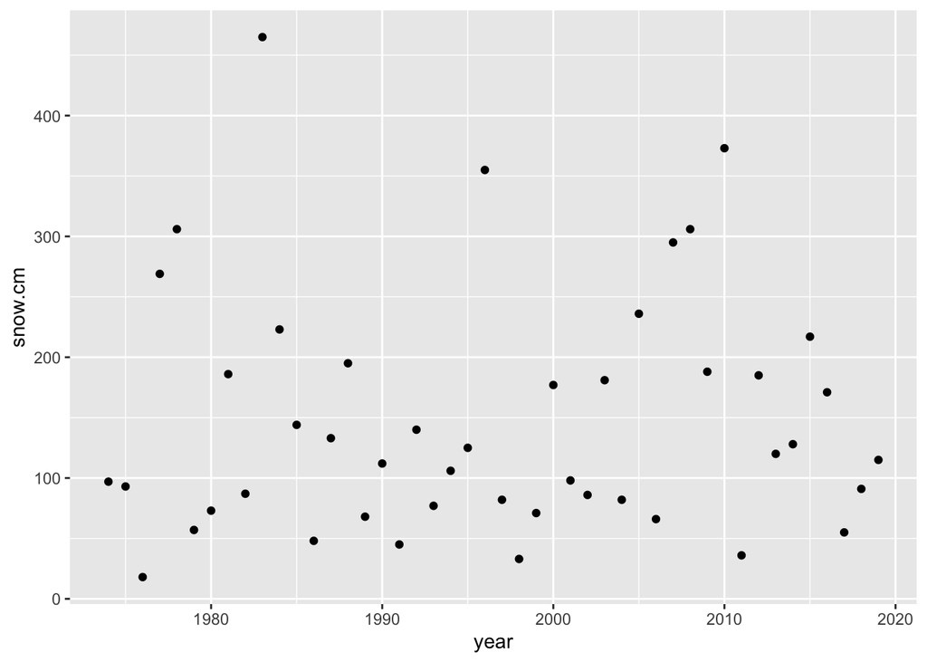

```r
# Guide for colors: https://www.datanovia.com/en/blog/ggplot-colors-best-tricks-you-will-love/
# Guide for ggplot: https://ggplot2.tidyverse.org

# In this example, we are going to snowfall in December

m <- 12 # we want to plot data from the 12th month

# first, we will create a basic graph
base <- ggplot(subset(s.month.clean, month == m),
         aes(x = year, y = snow.cm)) +
   geom_point()

base
```

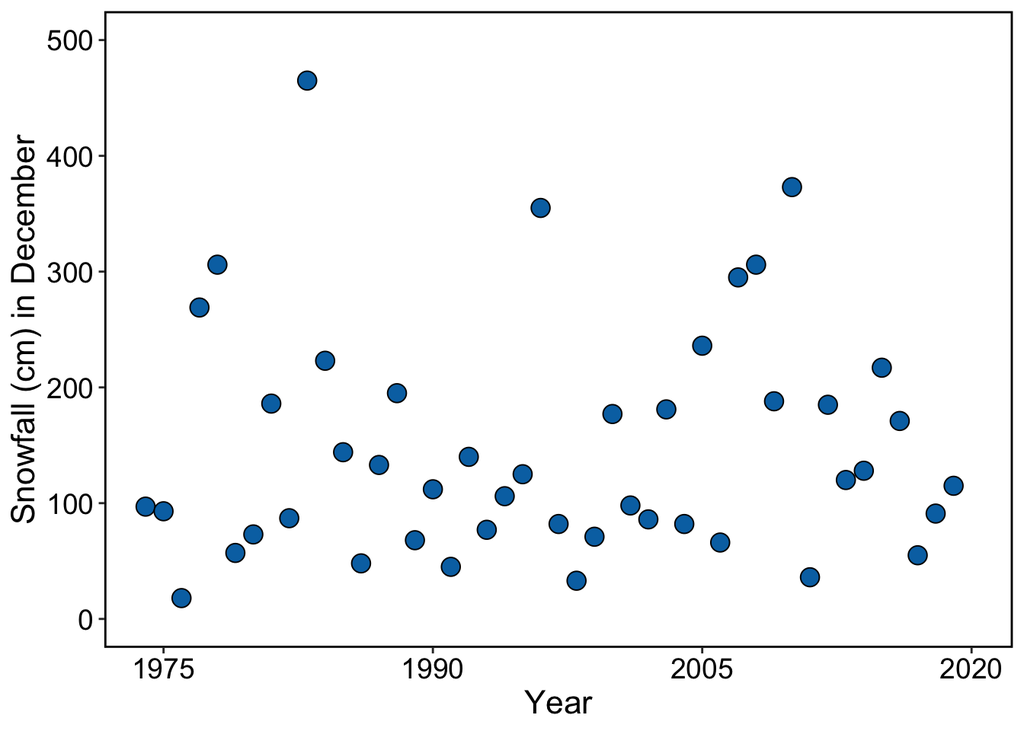

```r
# here is a fancier version
# There are SO many ways to use ggplot

fancy <-  ggplot(subset(s.month.clean, month == m),
         aes(x = year, y = snow.cm)) +
   geom_point(fill = "#0072B2", size = 4, pch = 21) +
   labs(x="Year", y ="Snowfall (cm) in December") +
   scale_x_continuous(limits = c(1974, 2020),
                      breaks = seq(1975, 2020, by = 15),
                      labels = c(1975, 1990, 2005, 2020)) +
   scale_y_continuous(limits = c(0, round(max(subset(s.month.clean,
                                             month == m)$snow.cm, na.rm = T),
                                             digits = -2))) +
   #annotate("text", x = 2014, y = 500, size = 6,
           #label = "data collected by b. barr") +
   theme(#axis.line = element_line(colour = "black", size = 0.25),
         axis.text = element_text(size = 14, colour="black"),
         axis.title = element_text(size = 16, colour = "black"),
         panel.border = element_rect(colour = "black", fill=NA, size=1),
         panel.background = element_blank(),
         legend.position='none')
fancy
```

# Goal 2: Plot yearly snow data

2.1: Select which snow variables you want to use from our original data frame

```r
s.year <- s3 %>%
        select(c(Winter.of, Total, on.grnd.)) %>%
        rename(c(winter.of = Winter.of, total.snow.cm = Total, date.bare = on.grnd.))

head(s.year)
```

```
##   winter.of total.snow.cm date.bare
## 1   1974-75          1073     6-Jun
## 2   1975-76           966    15-May
## 3   1976-77           474    26-Apr
## 4   1977-78          1387     4-Jun
## 5   1978-79          1346     1-Jun
## 6   1979-80          1542     7-Jun
```

2.2: Create a column with day of year for bare ground

```r
s.doy <- s.year %>%
    separate(winter.of, c("year", "year.2"), remove = T)  %>%
       mutate(year = as.numeric(year) + 1) %>%  # adjusting the winter file
    separate(date.bare, c("day", "month"), sep = "-") %>%
  mutate(dates = paste(year, month, day, sep ="-"),
         dateyr.bare = strptime(dates, format="%Y-%b-%d"), # from base R
         doy.bare = yday(dateyr.bare)) %>%  #from the lubridate package
  select(-c(year.2, day, month, dates, dateyr.bare))

head(s.doy)
```

```
##   year total.snow.cm doy.bare
## 1 1975          1073      157
## 2 1976           966      136
## 3 1977           474      116
## 4 1978          1387      155
## 5 1979          1346      152
## 6 1980          1542      159
```

2.3: Plot date of bare ground at the RMBL

```r
summary(lm(total.snow.cm ~ year, data = s.doy))
```

```
##
## Call:
## lm(formula = total.snow.cm ~ year, data = s.doy)
##
## Residuals:
##     Min      1Q  Median      3Q     Max
## -700.41 -133.11  -13.22  172.23  572.09
##
## Coefficients:
##              Estimate Std. Error t value Pr(>|t|)
## (Intercept) 12761.348   6107.472   2.089   0.0425 *
## year           -5.861      3.057  -1.917   0.0618 .
## ---
## Signif. codes:  0 '***' 0.001 '**' 0.01 '*' 0.05 '.' 0.1 ' ' 1
##
## Residual standard error: 275.3 on 44 degrees of freedom
## Multiple R-squared:  0.07707,    Adjusted R-squared:  0.0561
## F-statistic: 3.674 on 1 and 44 DF,  p-value: 0.06176
```

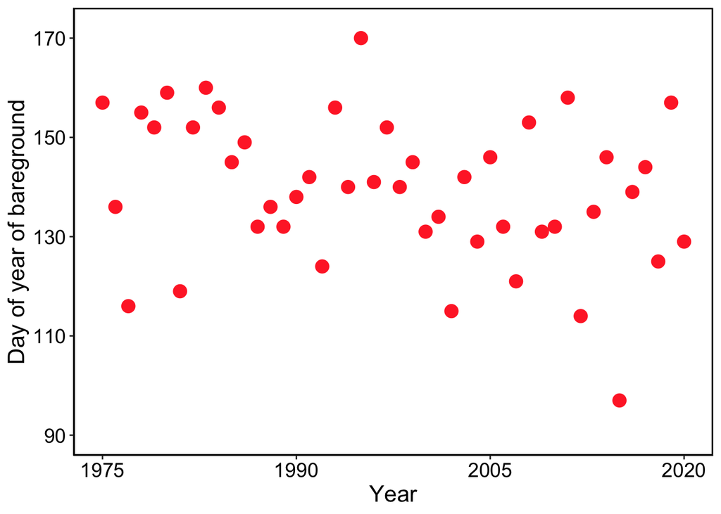

```r
bare <- ggplot(data = s.doy, aes(x = year, y = doy.bare)) +
   geom_point(colour = "firebrick1", size = 4) +
   labs(x="Year", y ="Day of year of bareground") +
   #geom_smooth(method = "lm", colour = "firebrick1", fill = "firebrick1") + #not statistically sig.
   scale_x_continuous(limits = c(1975, 2020),
                      breaks = seq(1975, 2020, by = 15),
                      labels = c(1975, 1990, 2005, 2020)) +
   scale_y_continuous(limits = c(90, 172),
                      breaks = seq(90, 170, by = 20)) +
   theme(plot.title = element_text(color="black", size=10),
         axis.line = element_line(colour = "black", size = 0.25),
         axis.text = element_text(size = 14, colour="black"),
         axis.title = element_text(size = 16, colour = "black"),
         panel.border = element_rect(colour = "black", fill=NA, size=1),
         panel.background = element_blank(),
         legend.position='none')
bare
```

```r
ggsave("bareground.pdf", units = "cm") # can add much more here! google: ggsave()
```

```
## Saving 17.8 x 12.7 cm image
```

2.4: Plot total snowfall at the RMBL

```r
# If we run a ver simple linear regression, we do not find a significant relationship
summary(lm(total.snow.cm ~ year, data = s.doy))
```

```
##
## Call:
## lm(formula = total.snow.cm ~ year, data = s.doy)
##
## Residuals:
##     Min      1Q  Median      3Q     Max
## -700.41 -133.11  -13.22  172.23  572.09
##
## Coefficients:
##              Estimate Std. Error t value Pr(>|t|)
## (Intercept) 12761.348   6107.472   2.089   0.0425 *
## year           -5.861      3.057  -1.917   0.0618 .
## ---
## Signif. codes:  0 '***' 0.001 '**' 0.01 '*' 0.05 '.' 0.1 ' ' 1
##
## Residual standard error: 275.3 on 44 degrees of freedom
## Multiple R-squared:  0.07707,    Adjusted R-squared:  0.0561
## F-statistic: 3.674 on 1 and 44 DF,  p-value: 0.06176
```

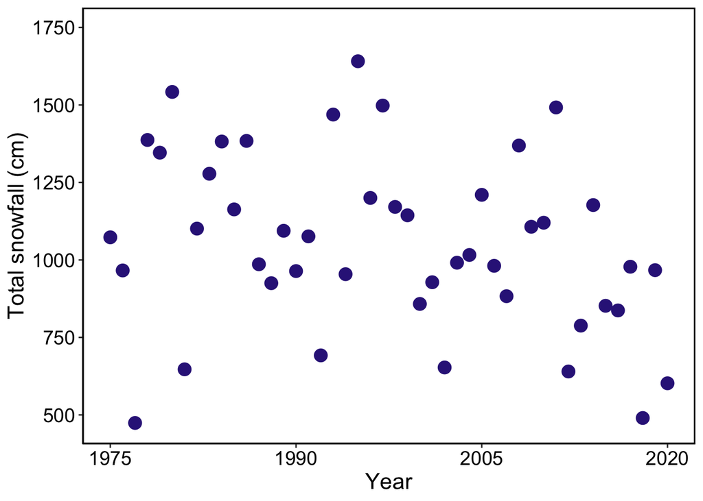

```r
total <- ggplot(data = s.doy, aes(x = year, y = total.snow.cm)) +
   geom_point(colour = "#332288", size = 4) +
   labs(x="Year", y ="Total snowfall (cm)") +
   #geom_smooth(method = "lm", colour = "#332288", fill = "#332288") + #not statistically sig.
   scale_x_continuous(limits = c(1975, 2020),
                      breaks = seq(1975, 2020, by = 15),
                      labels = c(1975, 1990, 2005, 2020)) +
   scale_y_continuous(limits = c(470, 1750),
                      breaks = seq(500, 1750, by = 250)) +
   theme(plot.title = element_text(color="black", size=10),
         axis.line = element_line(colour = "black", size = 0.25),
         axis.text = element_text(size = 14, colour="black"),
         axis.title = element_text(size = 16, colour = "black"),
         panel.border = element_rect(colour = "black", fill=NA, size=1),
         panel.background = element_blank(),
         legend.position='none')
total
```

2.5: Plot both total snowfall and date of bareground in the same plot

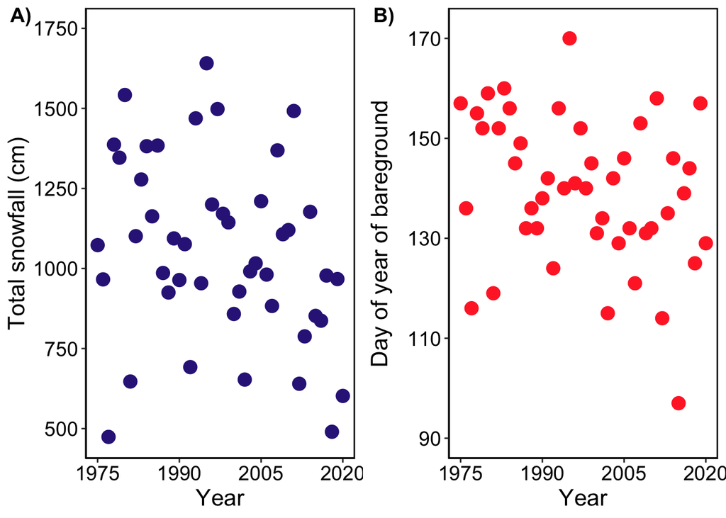

```r
ggarrange(total, bare,
          nrow = 1, ncol = 2,
          align = "hv",
          labels = c("A)", "B)"))
```

2.7 Bonus graph! Might not be useful to represent the data, but showing other ways ggplot can show data

```r
pal <- terrain.colors(nrow(s.doy))
summary(lm(doy.bare ~ year, data = s.doy))
```

```
##
## Call:
## lm(formula = doy.bare ~ year, data = s.doy)
##
## Residuals:
##     Min      1Q  Median      3Q     Max
## -37.013  -7.977   0.636  10.326  29.791
##
## Coefficients:
##             Estimate Std. Error t value Pr(>|t|)
## (Intercept) 758.3333   319.0941   2.377   0.0219 *
## year         -0.3098     0.1597  -1.940   0.0589 .
## ---
## Signif. codes:  0 '***' 0.001 '**' 0.01 '*' 0.05 '.' 0.1 ' ' 1
##
## Residual standard error: 14.38 on 44 degrees of freedom
## Multiple R-squared:  0.07877,    Adjusted R-squared:  0.05783
## F-statistic: 3.762 on 1 and 44 DF,  p-value: 0.05886
```

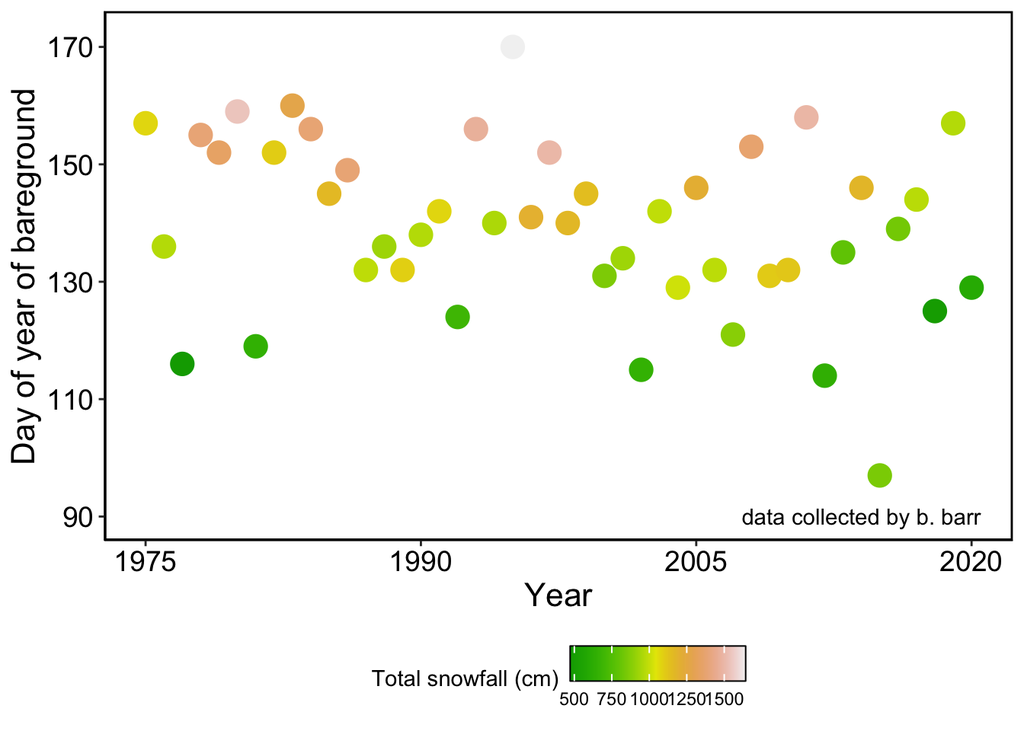

```r
bonus <- ggplot(data = s.doy, aes(x = year, y = doy.bare)) +
  geom_point(aes(colour = total.snow.cm), alpha =1 , size = 5) +
  scale_colour_gradientn(colours = pal,
                         guide = guide_colorbar(title = "Total snowfall (cm)",
                                        label = TRUE, draw.ulim = TRUE, draw.llim = TRUE,
                                        frame.colour = "black", frame.linewidth = 1,
                                        ticks.colour = "white", ticks.linewidth = 1,
                                        ticks = TRUE, label.position = "bottom",
                                        direction = 'horizontal'))  +
   labs(x="Year", y ="Day of year of bareground") +
   scale_x_continuous(limits = c(1975, 2020),
                      breaks = seq(1975, 2020, by = 15),
                      labels = c(1975, 1990, 2005, 2020)) +
   scale_y_continuous(limits = c(90, 172),
                      breaks = seq(90, 170, by = 20)) +
   annotate("text", x = 2014, y = 90, label = "data collected by b. barr") +
   theme(plot.title = element_text(color="black", size=10),
         axis.line = element_line(colour = "black", size = 0.25),
         axis.text = element_text(size = 14, colour="black"),
         axis.title = element_text(size = 16, colour = "black"),
         panel.border = element_rect(colour = "black", fill=NA, size=1),
         panel.background = element_blank(),
         legend.position='bottom')
bonus
```

## NOAA Crested Butte weather data

precipitation and temperature data: accessed on July 10, 2020: https://www.ncdc.noaa.gov/cdo-web/datasets/GHCND/stations/GHCND:USC00051959/detail

# Goal 3: Summarize and plot summer airtemperature in CB

3.1: Read in the data Note: This presentation does not go through how to check data quality and exploration, although the tools presented here can be used for that! Here, we are assuming all the downloaded data are perfect (which is NOT what you should ever assume)

```r
cb <- read.csv("cb_weather_temp.csv", header=T, sep=',')
colnames(cb)
```

```
## [1] "STATION"   "NAME"      "LATITUDE"  "LONGITUDE" "ELEVATION" "DATE"
## [7] "TMAX"      "TMIN"      "TOBS"
```

```r
# Sometimes when all of the headers are in capital letters, it feels like the data are yelling at me
# I like to change uppercase to lowercase, but this is just my preference
colnames(cb) <- tolower(colnames(cb))
colnames(cb)
```

```
## [1] "station"   "name"      "latitude"  "longitude" "elevation" "date"
## [7] "tmax"      "tmin"      "tobs"
```

```r
dim(cb)
```

```
## [1] 16773     9
```

3.2: Calculate daily mean temperature in min and max

```r
cb.mean <- cb %>%
              mutate(tmean = (tmax + tmin)/2)
head(cb.mean)
```

```
##       station                 name latitude longitude elevation   date  tmax
## 1 USC00051959 CRESTED BUTTE, CO US  38.8738 -106.9772    2702.7 1/1/74 -11.7
## 2 USC00051959 CRESTED BUTTE, CO US  38.8738 -106.9772    2702.7 1/2/74 -11.1
## 3 USC00051959 CRESTED BUTTE, CO US  38.8738 -106.9772    2702.7 1/3/74 -13.3
## 4 USC00051959 CRESTED BUTTE, CO US  38.8738 -106.9772    2702.7 1/4/74 -16.1
## 5 USC00051959 CRESTED BUTTE, CO US  38.8738 -106.9772    2702.7 1/5/74  -5.0
## 6 USC00051959 CRESTED BUTTE, CO US  38.8738 -106.9772    2702.7 1/6/74  -7.8
##    tmin  tobs  tmean
## 1 -26.7 -13.9 -19.20
## 2 -26.7 -21.1 -18.90
## 3 -35.0 -27.8 -24.15
## 4 -38.3 -26.1 -27.20
## 5 -29.4  -9.4 -17.20
## 6 -12.2 -10.0 -10.00
```

```r
dim(cb.mean)
```

```
## [1] 16773    10
```

3.3: Format date columns

```r
cb.date <- cb.mean %>%
              mutate(date = as.Date(date, "%m/%d/%y")) %>%
              mutate(month = month(date),
                     year = year(date),
                     day = day(date),
                     yday = yday(date))
head(cb.date)
```

```
##       station                 name latitude longitude elevation       date
## 1 USC00051959 CRESTED BUTTE, CO US  38.8738 -106.9772    2702.7 1974-01-01
## 2 USC00051959 CRESTED BUTTE, CO US  38.8738 -106.9772    2702.7 1974-01-02
## 3 USC00051959 CRESTED BUTTE, CO US  38.8738 -106.9772    2702.7 1974-01-03
## 4 USC00051959 CRESTED BUTTE, CO US  38.8738 -106.9772    2702.7 1974-01-04
## 5 USC00051959 CRESTED BUTTE, CO US  38.8738 -106.9772    2702.7 1974-01-05
## 6 USC00051959 CRESTED BUTTE, CO US  38.8738 -106.9772    2702.7 1974-01-06
##    tmax  tmin  tobs  tmean month year day yday
## 1 -11.7 -26.7 -13.9 -19.20     1 1974   1    1
## 2 -11.1 -26.7 -21.1 -18.90     1 1974   2    2
## 3 -13.3 -35.0 -27.8 -24.15     1 1974   3    3
## 4 -16.1 -38.3 -26.1 -27.20     1 1974   4    4
## 5  -5.0 -29.4  -9.4 -17.20     1 1974   5    5
## 6  -7.8 -12.2 -10.0 -10.00     1 1974   6    6
```

3.4: Summarize "summer" temperature

```r
cb.summer.temp <- cb.date %>%
                  filter(month == 6 | month == 7 | month == 8) %>%
                  group_by(year) %>%
                  summarize( mean = mean(tmean, na.rm = TRUE),
                    min = mean(tmin, na.rm = T),
                            max = mean(tmax, na.rm = T))
head(cb.summer.temp)
```

```
## # A tibble: 6 x 4
##    year  mean    min   max
##   <dbl> <dbl>  <dbl> <dbl>
## 1  1974 11.1   0.866  21.1
## 2  1975 10.6   1.44   19.8
## 3  1976 12.2   2.42   21.9
## 4  1977 13.2   3.39   23.0
## 5  1978 12.8   1.95   23.7
## 6  1979  9.65 -0.561  19.9
```

```r
tail(cb.summer.temp)
```

```
## # A tibble: 6 x 4
##    year  mean   min   max
##   <dbl> <dbl> <dbl> <dbl>
## 1  2015  13.0  3.27  22.7
## 2  2016  12.7  2.51  22.7
## 3  2017  13.2  2.91  23.4
## 4  2018  13.7  2.72  24.7
## 5  2019  13.0  2.74  23.2
## 6  2020  12.3  1.68  22.8
```

3.5: Reshape data for plotting

```r
cb.summer.gathered <- cb.summer.temp %>%
                  gather(key = "val", value = "temp", "mean":"max")
```

3.6: Plot mean, min, and max summer temperature over time

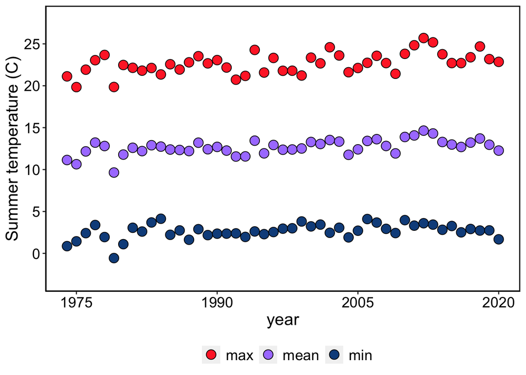

```r
summer <- ggplot(data = cb.summer.gathered, aes(x = year, y = temp), group = val) +
  geom_point(aes(fill = val), alpha =1 , size = 4, pch = 21) +
   labs(x="year", y ="Summer temperature (C)", fill = " ") +
   scale_x_continuous(limits = c(1974, 2020),
                      breaks = seq(1975, 2020, by = 15),
                      labels = c(1975, 1990, 2005, 2020)) +
   scale_y_continuous(limits = c(-3, 28),
                      breaks = seq(0, 25, by = 5)) +
   scale_fill_manual(breaks = c("max", "mean", "min"),
                       values=c("firebrick1", "mediumpurple1", "dodgerblue4")) +
   theme(plot.title = element_text(color="black", size=10),
         axis.line = element_line(colour = "black", size = 0.25),
         axis.text = element_text(size = 14, colour="black"),
         axis.title = element_text(size = 16, colour = "black"),
         panel.border = element_rect(colour = "black", fill=NA, size=1),
         panel.background = element_blank(),
         legend.position='bottom',
         legend.text=element_text(size=14))

summer
```